# Os_FIAs_da_mae

## Hackaton IFood

**Nome do grupo:** Os FIAs da mãe

#### Integrantes:

- Caíque Filipini
- Leonardo Farhat
- Jhonatta Makey

#### Qual é o problema que queremos resolver?

Buscamos entender se os pushs são efetivos a partir da análise do comportamento de compras do cliente.  
Para isso utilizamos o status_ifood de cada clienteou seja, se for 1, é um cliente [ativo, ressurrected ou new], se for 0, é um caso de [churn ou inativo].

#### Como abordamos o problema?

1) Análise exploratória a partir das bases de customer, orders e push para entender se os pushs eram relevantes ou não;  
2) Criação de um modelo de classificação, com status_ifood como target para entender como os clientes se comportam.

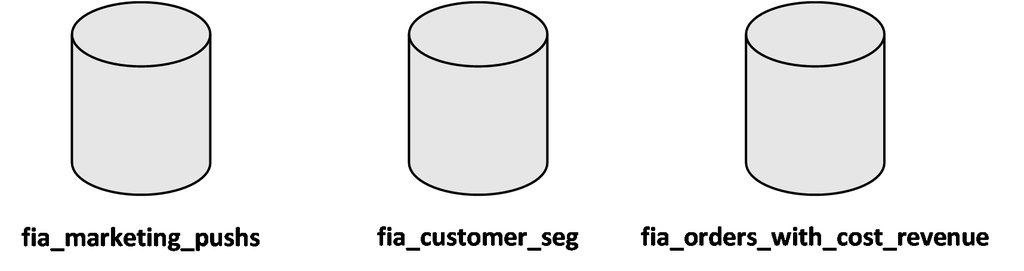

```python
Image('datasets.png')
```

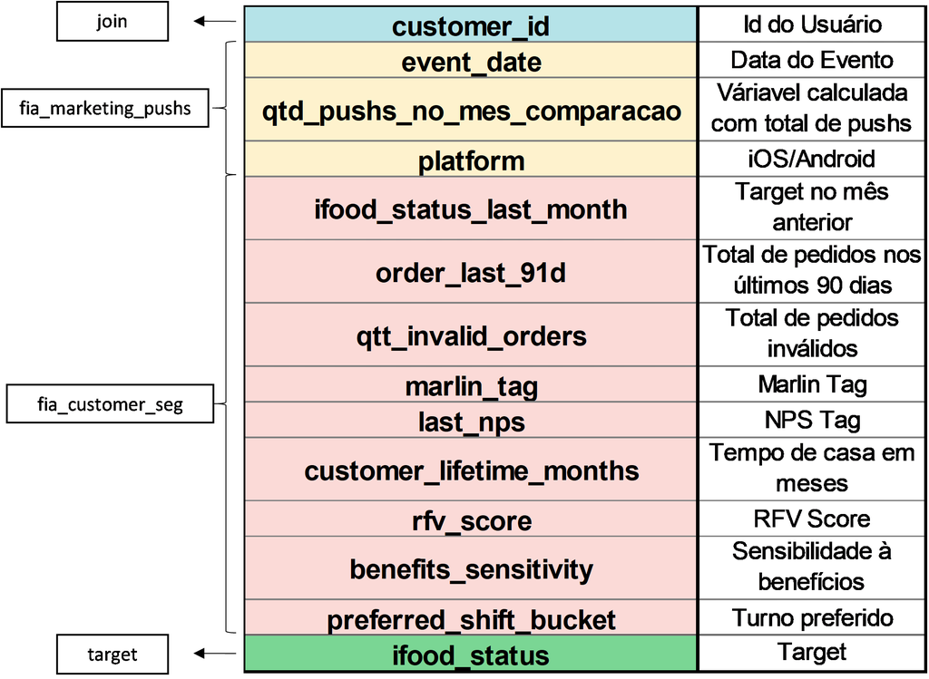

```python
Image('features.png', width=1000)
```

#### Sumário

- 1. Carregando as bibliotecas
- 2. Carregando os dados
- 3. Explorando os dados
- 4. Arrumando os dados
- 5. Treinando o modelo
- 6. Avaliando o modelo
- 7. Traçando os perfis
- 8. Valuation
- 9. Conclusões
- 10. Próximos Passos

#### 1. Carregando as bibliotecas

```python
import pandas as pd
from xgboost import XGBClassifier
from xgboost import plot_importance
from sklearn.model_selection import StratifiedKFold
from sklearn.model_selection import RandomizedSearchCV
from sklearn.metrics import roc_auc_score, accuracy_score, classification_report, precision_recall_curve, f1_score, roc_curve, confusion_matrix
from matplotlib import pyplot
import seaborn as sns
from IPython.display import Image

# configurando o notebook:

from IPython.core.display import display, HTML
display(HTML("<style>.container { width:100% !important; }</style>"))

import warnings
warnings.filterwarnings("ignore")

pd.options.display.max_rows = 999
```

Sumário

#### 2. Carregando os dados

```python
df_customer = pd.read_csv('customer_features.csv')
df_push = pd.read_csv('push_features.csv', sep=';')
```

```python
df_customer.head()
```

|  | customer_id | segmentation_month | ifood_status_last_month | orders_last_91d | qtt_invalid_orders | marlin_tag | last_nps | customer_lifetime_months | rfv_score | benefits_sensitivity | preferred_shift_bucket | ifood_status |
| --- | --- | --- | --- | --- | --- | --- | --- | --- | --- | --- | --- | --- |
| 0 | 6677d5e78e4627cf80ae3ea3281869183c946c366efc43... | 2019-10-01 | Inactive | 9.0 | 1 | 4. Retention Carp | Promoter | 19 | 4.0 | 0.888889 | 5 | Inactive |
| 1 | 5e57de756833068ca492f110539c987964b9d0e57219e2... | 2019-07-01 | Active | 15.0 | 0 | 1. Marlin | Promoter | 39 | 3.0 | 0.400000 | 5 | Active |
| 2 | e9b6de166321d875877dc12dd1856f0edc90fea9d8bf3e... | 2019-10-01 | Inactive | 8.0 | 0 | 1. Marlin | Promoter | 4 | 4.0 | 0.375000 | 6 | Inactive |
| 3 | 696ea0a48c8156e07ff7ad21ac74e3d8cf8dc9ea9e05b7... | 2019-10-01 | Inactive | 4.0 | 0 | 4. Retention Carp | Promoter | 17 | 3.0 | 1.000000 | 5 | Inactive |
| 4 | 13974eea8c9dd51f15eb82e96ae1b85c010f1be75e397a... | 2019-10-01 | Churn | 5.0 | 4 | 2. Tilapia | Sem Avaliacoes | 12 | 3.0 | 0.600000 | 6 | Inactive |

```python
df_push.head()
```

|  | customer_id | platform | push_count | segmentation_month |
| --- | --- | --- | --- | --- |
| 0 | a08b935432a0940f3f6c73adb55b65b93bd5e1bd372402... | ios | 85 | 2019-07-01 |
| 1 | 0f5a07ae77acbfb122873a257d13e4f1bb0a2fc78b4d57... | ios | 85 | 2019-07-01 |
| 2 | 6737d8b6f4adfa4d50fc9bb77223ce0274cbb7658f5cab... | android | 44 | 2019-08-01 |
| 3 | 2d3b3a588a9f6134bed5400da7accd7b181a04c0634848... | ios | 142 | 2019-07-01 |
| 4 | af57e9cdfa254fcee73c757e6cfbb197f428509c4e3fa4... | ios | 90 | 2019-11-01 |

```python
# dando join nas bases
df_model = df_customer.merge(df_push, on=['customer_id', 'segmentation_month'], how='inner').reset_index(drop=True)
```

```python
df_model.head()
```

|  | customer_id | segmentation_month | ifood_status_last_month | orders_last_91d | qtt_invalid_orders | marlin_tag | last_nps | customer_lifetime_months | rfv_score | benefits_sensitivity | preferred_shift_bucket | ifood_status | platform | push_count |
| --- | --- | --- | --- | --- | --- | --- | --- | --- | --- | --- | --- | --- | --- | --- |
| 0 | 6677d5e78e4627cf80ae3ea3281869183c946c366efc43... | 2019-10-01 | Inactive | 9.0 | 1 | 4. Retention Carp | Promoter | 19 | 4.0 | 0.888889 | 5 | Inactive | android | 126 |
| 1 | 5e57de756833068ca492f110539c987964b9d0e57219e2... | 2019-07-01 | Active | 15.0 | 0 | 1. Marlin | Promoter | 39 | 3.0 | 0.400000 | 5 | Active | android | 146 |
| 2 | e9b6de166321d875877dc12dd1856f0edc90fea9d8bf3e... | 2019-10-01 | Inactive | 8.0 | 0 | 1. Marlin | Promoter | 4 | 4.0 | 0.375000 | 6 | Inactive | android | 58 |
| 3 | 13974eea8c9dd51f15eb82e96ae1b85c010f1be75e397a... | 2019-10-01 | Churn | 5.0 | 4 | 2. Tilapia | Sem Avaliacoes | 12 | 3.0 | 0.600000 | 6 | Inactive | android | 187 |
| 4 | e5aa9cdb5eedd9f02cad42f40f24f08d56bfdd1a6b2aad... | 2019-11-01 | Churn | 1.0 | 0 | 4. Retention Carp | Sem Avaliacoes | 22 | 2.0 | 1.000000 | 5 | Inactive | ios | 82 |

```python
df_model.shape
```

```
(158776, 14)
```

Sumário

#### 3. Explorando os dados

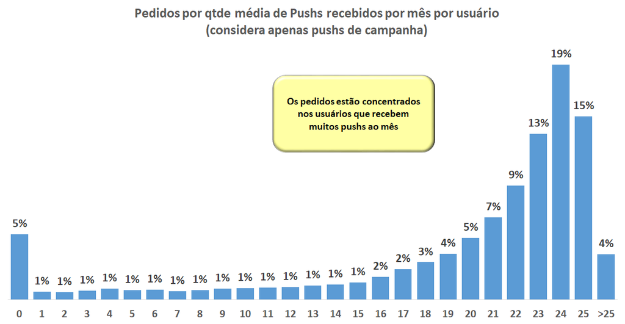

```python
Image('Gráfico 1.png')
```

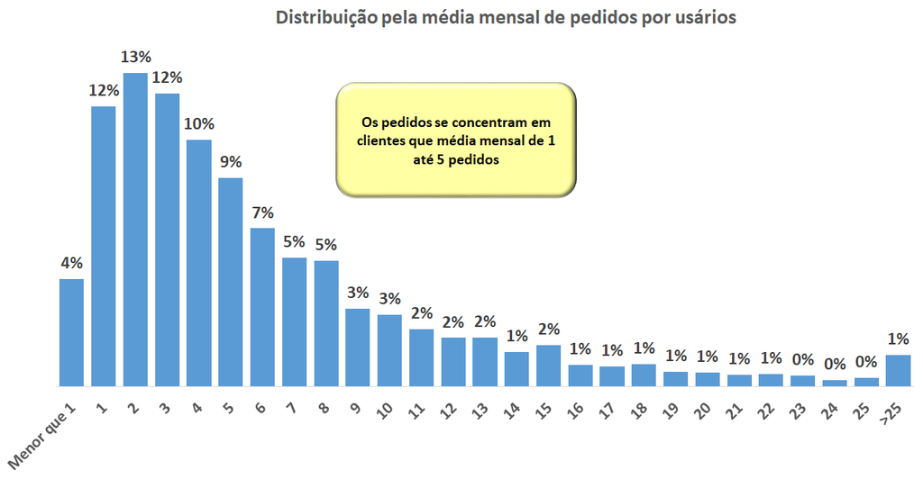

```python
Image('Gráfico 2.png')
```

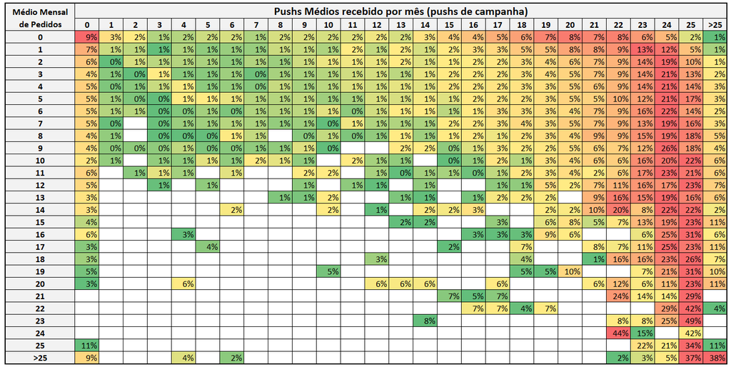

```python
Image('Mapa de Calor.png')
```

Sumário

#### 4. Arrumando os dados

```python
# separando os tipos das variáveis:
indice = ['customer_id']
ref = ['segmentation_month']
target = ['ifood_status']
vars_cat = ['ifood_status_last_month', 'marlin_tag', 'last_nps', 'preferred_shift_bucket', 'platform']
vars_num = ['orders_last_91d', 'qtt_invalid_orders', 'customer_lifetime_months', 'rfv_score', 'benefits_sensitivity', 'push_count']

# ordenando o dataframe:
df_model = df_model[indice + ref + vars_cat + vars_num + target]

df_model.head()
```

|  | customer_id | segmentation_month | ifood_status_last_month | marlin_tag | last_nps | preferred_shift_bucket | platform | orders_last_91d | qtt_invalid_orders | customer_lifetime_months | rfv_score | benefits_sensitivity | push_count | ifood_status |
| --- | --- | --- | --- | --- | --- | --- | --- | --- | --- | --- | --- | --- | --- | --- |
| 0 | 6677d5e78e4627cf80ae3ea3281869183c946c366efc43... | 2019-10-01 | Inactive | 4. Retention Carp | Promoter | 5 | android | 9.0 | 1 | 19 | 4.0 | 0.888889 | 126 | Inactive |
| 1 | 5e57de756833068ca492f110539c987964b9d0e57219e2... | 2019-07-01 | Active | 1. Marlin | Promoter | 5 | android | 15.0 | 0 | 39 | 3.0 | 0.400000 | 146 | Active |
| 2 | e9b6de166321d875877dc12dd1856f0edc90fea9d8bf3e... | 2019-10-01 | Inactive | 1. Marlin | Promoter | 6 | android | 8.0 | 0 | 4 | 4.0 | 0.375000 | 58 | Inactive |
| 3 | 13974eea8c9dd51f15eb82e96ae1b85c010f1be75e397a... | 2019-10-01 | Churn | 2. Tilapia | Sem Avaliacoes | 6 | android | 5.0 | 4 | 12 | 3.0 | 0.600000 | 187 | Inactive |
| 4 | e5aa9cdb5eedd9f02cad42f40f24f08d56bfdd1a6b2aad... | 2019-11-01 | Churn | 4. Retention Carp | Sem Avaliacoes | 5 | ios | 1.0 | 0 | 22 | 2.0 | 1.000000 | 82 | Inactive |

```python
# definindo a target:
df_model['target'] = df_model['ifood_status'].apply(lambda x: 1 if x in ['New', 'Resurrected', 'Active'] else 0)
df_model.drop('ifood_status', axis=1, inplace=True)
df_model.head()
```

|  | customer_id | segmentation_month | ifood_status_last_month | marlin_tag | last_nps | preferred_shift_bucket | platform | orders_last_91d | qtt_invalid_orders | customer_lifetime_months | rfv_score | benefits_sensitivity | push_count | target |
| --- | --- | --- | --- | --- | --- | --- | --- | --- | --- | --- | --- | --- | --- | --- |
| 0 | 6677d5e78e4627cf80ae3ea3281869183c946c366efc43... | 2019-10-01 | Inactive | 4. Retention Carp | Promoter | 5 | android | 9.0 | 1 | 19 | 4.0 | 0.888889 | 126 | 0 |
| 1 | 5e57de756833068ca492f110539c987964b9d0e57219e2... | 2019-07-01 | Active | 1. Marlin | Promoter | 5 | android | 15.0 | 0 | 39 | 3.0 | 0.400000 | 146 | 1 |
| 2 | e9b6de166321d875877dc12dd1856f0edc90fea9d8bf3e... | 2019-10-01 | Inactive | 1. Marlin | Promoter | 6 | android | 8.0 | 0 | 4 | 4.0 | 0.375000 | 58 | 0 |
| 3 | 13974eea8c9dd51f15eb82e96ae1b85c010f1be75e397a... | 2019-10-01 | Churn | 2. Tilapia | Sem Avaliacoes | 6 | android | 5.0 | 4 | 12 | 3.0 | 0.600000 | 187 | 0 |
| 4 | e5aa9cdb5eedd9f02cad42f40f24f08d56bfdd1a6b2aad... | 2019-11-01 | Churn | 4. Retention Carp | Sem Avaliacoes | 5 | ios | 1.0 | 0 | 22 | 2.0 | 1.000000 | 82 | 0 |

```python
df_model.target.value_counts(normalize=True)*100
```

```
1    70.63725
0    29.36275
Name: target, dtype: float64
```

```python
df_model_filter = df_model.drop(['customer_id', 'segmentation_month'], axis=1)
```

```python
df_model_filter['preferred_shift_bucket'] = df_model_filter['preferred_shift_bucket'].astype('object')
```

```python
# dummizando as variáveis categóricas:
df_model_dummies = pd.get_dummies(df_model_filter, prefix=vars_cat, drop_first=True)
df_model_dummies.head()
```

|  | orders_last_91d | qtt_invalid_orders | customer_lifetime_months | rfv_score | benefits_sensitivity | push_count | target | ifood_status_last_month_Churn | ifood_status_last_month_Inactive | ifood_status_last_month_New | ... | last_nps_Neutral | last_nps_Promoter | last_nps_Sem Avaliacoes | preferred_shift_bucket_1 | preferred_shift_bucket_2 | preferred_shift_bucket_3 | preferred_shift_bucket_4 | preferred_shift_bucket_5 | preferred_shift_bucket_6 | platform_ios |
| --- | --- | --- | --- | --- | --- | --- | --- | --- | --- | --- | --- | --- | --- | --- | --- | --- | --- | --- | --- | --- | --- |
| 0 | 9.0 | 1 | 19 | 4.0 | 0.888889 | 126 | 0 | 0 | 1 | 0 | ... | 0 | 1 | 0 | 0 | 0 | 0 | 0 | 1 | 0 | 0 |
| 1 | 15.0 | 0 | 39 | 3.0 | 0.400000 | 146 | 1 | 0 | 0 | 0 | ... | 0 | 1 | 0 | 0 | 0 | 0 | 0 | 1 | 0 | 0 |
| 2 | 8.0 | 0 | 4 | 4.0 | 0.375000 | 58 | 0 | 0 | 1 | 0 | ... | 0 | 1 | 0 | 0 | 0 | 0 | 0 | 0 | 1 | 0 |
| 3 | 5.0 | 4 | 12 | 3.0 | 0.600000 | 187 | 0 | 1 | 0 | 0 | ... | 0 | 0 | 1 | 0 | 0 | 0 | 0 | 0 | 1 | 0 |
| 4 | 1.0 | 0 | 22 | 2.0 | 1.000000 | 82 | 0 | 1 | 0 | 0 | ... | 0 | 0 | 1 | 0 | 0 | 0 | 0 | 1 | 0 | 1 |

5 rows × 24 columns

```python
# definindo X e y:
X = df_model_dummies.drop('target', axis=1)
y = df_model_dummies['target']
```

Sumário

#### 5. Treinando o modelo

```python
# definindo a métrica de otimização:
metrica = 'roc_auc'
```

```python
# definindo o método de avaliação do modelo:
folds = 3
cv = StratifiedKFold(n_splits=folds, shuffle = True, random_state = 42)
```

```python
# definindo os parâmetros:
params = {
        'min_child_weight': [5, 10],
        'gamma': [0.5, 1.5, 5],
        'subsample': [0.6, 0.8, 1.0],
        'max_depth': [3, 4, 5]
        }
```

```python
# definindo o modelo:
xgb = XGBClassifier()
model = RandomizedSearchCV(xgb, param_distributions=params, scoring=metrica, n_jobs=-1, cv=cv, random_state=42)
```

```python
# rodando o modelo
model.fit(X, y)
```

```
RandomizedSearchCV(cv=StratifiedKFold(n_splits=3, random_state=42, shuffle=True),
                   error_score='raise-deprecating',
                   estimator=XGBClassifier(base_score=0.5, booster='gbtree',
                                           colsample_bylevel=1,
                                           colsample_bynode=1,
                                           colsample_bytree=1, gamma=0,
                                           learning_rate=0.1, max_delta_step=0,
                                           max_depth=3, min_child_weight=1,
                                           missing=None, n_estimators=100,
                                           n_jobs=1, nthread=None...
                                           random_state=0, reg_alpha=0,
                                           reg_lambda=1, scale_pos_weight=1,
                                           seed=None, silent=None, subsample=1,
                                           verbosity=1),
                   iid='warn', n_iter=10, n_jobs=-1,
                   param_distributions={'gamma': [0.5, 1.5, 5],
                                        'max_depth': [3, 4, 5],
                                        'min_child_weight': [5, 10],
                                        'subsample': [0.6, 0.8, 1.0]},
                   pre_dispatch='2*n_jobs', random_state=42, refit=True,
                   return_train_score=False, scoring='roc_auc', verbose=0)
```

```python
# melhor modelo
model.best_estimator_
```

```
XGBClassifier(base_score=0.5, booster='gbtree', colsample_bylevel=1,
              colsample_bynode=1, colsample_bytree=1, gamma=5,
              learning_rate=0.1, max_delta_step=0, max_depth=5,
              min_child_weight=5, missing=None, n_estimators=100, n_jobs=1,
              nthread=None, objective='binary:logistic', random_state=0,
              reg_alpha=0, reg_lambda=1, scale_pos_weight=1, seed=None,
              silent=None, subsample=0.6, verbosity=1)
```

```python
model = XGBClassifier(base_score=0.5, booster='gbtree', colsample_bylevel=1,
              colsample_bynode=1, colsample_bytree=1, gamma=5,
              learning_rate=0.1, max_delta_step=0, max_depth=5,
              min_child_weight=5, missing=None, n_estimators=100, n_jobs=1,
              nthread=None, objective='binary:logistic', random_state=0,
              reg_alpha=0, reg_lambda=1, scale_pos_weight=1, seed=None,
              silent=None, subsample=0.6, verbosity=1)
```

```python
model.fit(X,y)
```

```
XGBClassifier(base_score=0.5, booster='gbtree', colsample_bylevel=1,
              colsample_bynode=1, colsample_bytree=1, gamma=5,
              learning_rate=0.1, max_delta_step=0, max_depth=5,
              min_child_weight=5, missing=None, n_estimators=100, n_jobs=1,
              nthread=None, objective='binary:logistic', random_state=0,
              reg_alpha=0, reg_lambda=1, scale_pos_weight=1, seed=None,
              silent=None, subsample=0.6, verbosity=1)
```

```python
orders_last91d
rfv_score
customer_lifetime_months
push_count
ifood_status_last_month
benefits_sensitivity
```

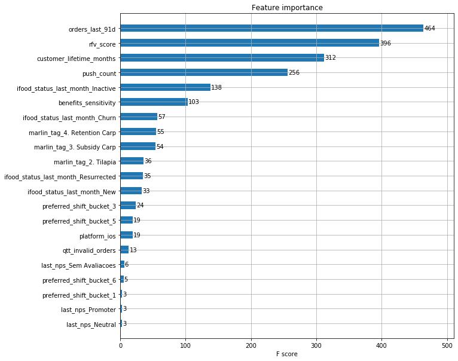

```python
ax = plot_importance(model, height=0.5, ylabel=None, grid=True)
fig = ax.figure
fig.set_size_inches(10,10)
pyplot.show()
```

Sumário

#### 6. Avaliando o modelo

*Matriz de confusão:*

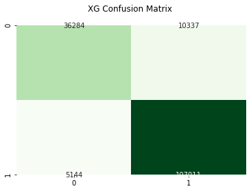

```
accuracy_score (50%): 90.25%*
```

```python
cm_xgb = confusion_matrix(y, model.predict(X))

pyplot.title("XG Confusion Matrix \n")
sns.heatmap(cm_xgb,cbar=False,annot=True,cmap="Greens",fmt="d")
pyplot.tight_layout
pyplot.show()

print('accuracy_score (50%): {:.2%}*'.format(accuracy_score(y, model.predict(X))))
```

*Classification report:*

```python
print(classification_report(y, model.predict(X)))
```

```
              precision    recall  f1-score   support

           0       0.88      0.78      0.82     46621
           1       0.91      0.95      0.93    112155

    accuracy                           0.90    158776
   macro avg       0.89      0.87      0.88    158776
weighted avg       0.90      0.90      0.90    158776
```

*ROC Curve:*

```python
y_predict = model.predict_proba(X)
fpr, tpr, thresholds = roc_curve(y, y_predict.transpose()[1])
```

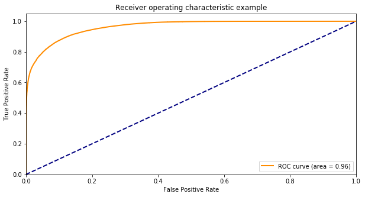

```python
pyplot.figure(figsize=(10,5))
lw = 2
pyplot.plot(fpr, tpr, color='darkorange',
         lw=lw, label='ROC curve (area = %0.2f)' % roc_auc_score(y, y_predict.transpose()[1]))
pyplot.plot([0, 1], [0, 1], color='navy', lw=lw, linestyle='--')
pyplot.xlim([0.0, 1.0])
pyplot.ylim([0.0, 1.05])
pyplot.xlabel('False Positive Rate')
pyplot.ylabel('True Positive Rate')
pyplot.title('Receiver operating characteristic example')
pyplot.legend(loc="lower right")
pyplot.show()
```

Sumário

#### 7. Traçando os perfis

```python
vars_num_boxplot = ['orders_last_91d', 'rfv_score', 'benefits_sensitivity', 'customer_lifetime_months', 'push_count']
```

```python
df_model[df_model['target'] == 0][vars_num_boxplot].describe()
```

|  | orders_last_91d | rfv_score | benefits_sensitivity | customer_lifetime_months | push_count |
| --- | --- | --- | --- | --- | --- |
| count | 46615.000000 | 46615.000000 | 46615.000000 | 46621.000000 | 46621.000000 |
| mean | 4.832479 | 2.951346 | 0.654545 | 15.399262 | 49.055705 |
| std | 5.111594 | 0.601582 | 0.363602 | 14.979904 | 52.953788 |
| min | 1.000000 | 2.000000 | 0.000000 | 0.000000 | 1.000000 |
| 25% | 2.000000 | 3.000000 | 0.400000 | 4.000000 | 14.000000 |
| 50% | 3.000000 | 3.000000 | 0.750000 | 10.000000 | 42.000000 |
| 75% | 6.000000 | 3.000000 | 1.000000 | 23.000000 | 64.000000 |
| max | 88.000000 | 5.000000 | 1.000000 | 94.000000 | 1716.000000 |

```python
df_model[df_model['target'] == 1][vars_num_boxplot].describe()
```

|  | orders_last_91d | rfv_score | benefits_sensitivity | customer_lifetime_months | push_count |
| --- | --- | --- | --- | --- | --- |
| count | 112155.000000 | 112155.000000 | 112155.000000 | 112155.000000 | 112155.000000 |
| mean | 10.996202 | 2.540038 | 0.654624 | 20.887825 | 80.716794 |
| std | 11.223511 | 0.640882 | 0.309189 | 17.400033 | 83.459685 |
| min | 1.000000 | 1.000000 | 0.000000 | 0.000000 | 1.000000 |
| 25% | 4.000000 | 2.000000 | 0.444444 | 7.000000 | 39.000000 |
| 50% | 8.000000 | 3.000000 | 0.700000 | 16.000000 | 63.000000 |
| 75% | 14.000000 | 3.000000 | 1.000000 | 32.000000 | 96.000000 |
| max | 213.000000 | 4.000000 | 1.000000 | 94.000000 | 3517.000000 |

Sumário

#### 8. Valuation

```python
df_revenue = pd.read_csv('customer_revenue.csv', sep=';')
```

```python
df_model['status_anterior'] = df_model['ifood_status_last_month'].apply(lambda x: 1 if x in ['New', 'Resurrected', 'Active'] else 0)
df_model['predicted'] = model.predict(X)
df_model_valuation = df_model.copy()
```

```python
df_model_valuation = df_model_valuation[['customer_id', 'segmentation_month', 'target', 'status_anterior', 'predicted']]
df_model_valuation['soma'] = df_model_valuation['status_anterior'] + df_model_valuation['target']
df_model_valuation = df_model_valuation[df_model_valuation['soma'] == 1]
df_model_valuation.drop('soma', axis=1, inplace=True)
df_model_valuation['alteracao'] = df_model_valuation['status_anterior'].apply(lambda x: 'veio' if x == 0 else 'foi_embora')
df_model_valuation['acertou'] = df_model_valuation['target'] + df_model_valuation['predicted']
df_model_valuation_final = df_model_valuation[df_model_valuation['acertou'] != 1]
```

```python
valuation_anual = df_model_valuation_final.merge(df_revenue, on=['customer_id', 'segmentation_month'], how='inner').reset_index(drop=True)['sum_general_net_profit'].sum() / 6 * 12
```

```python
print('valuation: R$ {:.2f}'.format(valuation_anual), ', considerando somente os 30 mil clientes das bases disponibilizadas.')
```

```
valuation: R$ 431740.40 , considerando somente os 30 mil clientes das bases disponibilizadas.
```

Sumário

Sumário

#### 10. Propostas de inovação

- Melhor momento de enviar o push (dia da semana, horário e localização instantânea do cliente)
- Escolher os melhores tipos de push para cada perfil de cliente

Sumário

### Obrigado :)